# Assignment 3:

# SMS Spam classifier using Support Vector Machines

## Introduction

Many email services today provide spam filters that are able to classify an email into spam and non-spam/ham email with high accuracy. In this exercise, you build a SMS spam classifier. The focus in this exercise is in data preparation and feature engineering. You will later use your designed features in a Support Vector Machine (SVM) classifier.

In particular, you need to convert each SMS into a feature vector $x \in \mathbb{R}^n$ . The following parts of the exercise will walk you through how such a feature vector can be constructed from an SMS.

The dataset included for this exercise is the [SMS Spam Collection Data Set](https://archive.ics.uci.edu/ml/datasets/SMS+Spam+Collection) from the publication:

`Almeida, Tiago A., José María G. Hidalgo, and Akebo Yamakami. "Contributions to the study of SMS spam filtering: new collection and results." Proceedings of the 11th ACM symposium on Document engineering. 2011.`

```python
# used for manipulating directory paths
import os

# Scientific and vector computation for python
import numpy as np

# Import regular expressions to process sms
import re

# Plotting library
from matplotlib import pyplot

# SVM model
from sklearn import svm, model_selection

# for computing ROC and P-R curves
from sklearn import metrics

# library written for this exercise providing additional functions for assignment submission, and others
import utils

# might wanna use that for counting the occurences
from collections import Counter

# a powerful data toolbox; here only used for loading csv file
import pandas as pd

# tells matplotlib to embed plots within the notebook
%matplotlib inline

# grader object
grader=utils.Grader()

# SET YOUR Authentication Token. To get the token login to http://evalml.da.private.hm.edu/ and check the User info menu item.
AUTH_TOKEN = "cd4a9aa7782d5a61a41c6dd48746e426d1f9a09a"
grader.setToken(AUTH_TOKEN)
```

## Submission and Grading

After completing each part of the assignment you are asked to submit your results. In the following table you will find the overview over the different tasks that you need to perform:

| Section | Part | Submitted Function | Points |
| --- | --- | --- | --- |
| 1 | SMS Preprocessing | `preprocessSMS` | 15 |
| 2 | Dataset splits | `datasetSplits` | 10 |
| 3 | Create Vocabulary | `createVocabulary` | 20 |
| 4 | Word mapping | `wordMapping` | 15 |
| 5 | Feature Extraction | `featureExtraction` | 10 |
| 6 | SVM Training | `svmTraining` | 10 |
| 7 | Hyperparameter Tuning | `hyperparameterTuning` | 20 |
| 8 | ROC curve | - | - |
|  | Total Points |  | 100 |

You are allowed to submit your solutions multiple times. Correct results are not updated anymore.

At the end of each section, we have a cell which contains code for submitting the solutions thus far to the grader. Execute the cell to see your score up to the current section. For all your work to be submitted properly, you must execute those cells at least once. They must also be re-executed everytime the submitted function is updated. In the first half of this exercise, you will be guided through feature engineering for our SMS spam classifier. In the next half of the exercise, you will be using support vector machines to build a spam classifier, evaluate it, and optional, improve it.

## 1 SMS Preprocessing

Again, before starting on a machine learning task, it is usually helpful to take a look at the dataset. The figure below shows a sample SMS that contains a URL and some numbers. amounts.

[figure not shown]

While many SMS would contain similar types of entities (e.g., numbers, other URLs, or other email addresses), the specific entities (e.g., the specific URL or specific dollar amount) will be different in almost every SMS. Therefore, one method often employed in pre-processing is to “normalize” these values, so that all URLs are treated the same, all numbers are treated the same, etc. For example, we could replace each URL in the SMS with the unique string “httpaddr” to indicate that a URL was present.

Normalizing those values has the effect of letting the spam classifier make a classification decision based on whether any URL was present, rather than whether a specific URL was present. This typically improves the performance of a spam classifier, since spammers often randomize the URLs, and thus the odds of seeing any particular URL again in a new piece of spam is very small. Note that this process could also be seen as a form of regularization, since it makes the data simpler and since numbers and adresses might occur in a spam and ham (non-spam) messages, it makes this particular unimportant as feature dimension

In the function `processSMS` below, the following normalization steps are already applied:

- **Lower-casing**: The entire SMS is converted into lower case, so that captialization is ignored (e.g., IndIcaTE is treated the same as Indicate).
- **Stripping HTML**: All HTML tags are removed from the SMS. Many SMS often come with HTML formatting; we remove all the HTML tags, so that only the content remains.
- **Normalizing URLs**: All URLs are replaced with the text “httpaddr”.
- **Normalizing Email Addresses**: All email addresses are replaced with the text “emailaddr”.
- **Normalizing Numbers**: All numbers are replaced with the text “number”.
- **Normalizing Dollars / Euros**: All dollar / euro signs ($/€) are replaced with the text “dollar"/"euro”.
- **Removal of non-words**: Non-words and punctuation have been removed. All white spaces (tabs, newlines, spaces) have all been trimmed to a single space character.

Your remaining task before adding the word to the normalized sms string is to remove all remaining non alphanumeric characters. You should then create the preprocessed normalized sms from all preprocessed words.

```python
def processSMS(sms_content, verbose=False):
    """
    Preprocesses the body of an SMS and returns a list of indices
    of the words contained in the SMS.

    Parameters
    ----------
    sms_content : str
        A string containing the original SMS string.

    verbose : bool
        If True, print the resulting SMS after processing.

    Returns
    -------
    sms_content_normalzed : str
         A string containing teh normalized version of the input SMS.

    Instructions
    ------------
    Most of the normalization is already implemented.
    Your only left over normlaization task is to remove any remaining non alphanumeric characters in word.
    You should do this on a per word basis.
    At the end make sure that you return a valid string containing the prerocessed version if the input SMS.
    """
    # ========================== Preprocess SMS ===========================
    # Lower case
    sms_content = sms_content.lower()

    # Handle Numbers
    # Look for one or more characters between 0-9
    sms_content = re.compile('[0-9]+').sub(' number ', sms_content)

    # Handle URLS
    # Look for strings starting with http:// or https://
    sms_content = re.compile('((http|https)://|www.)[^\\s]*').sub(' httpaddr ', sms_content)

    # Handle Email Addresses
    # Look for strings with @ in the middle
    sms_content = re.compile('[^\\s]+@[^\\s]+').sub(' emailaddr ', sms_content)

    # Handle $ sign
    sms_content = re.compile('[$]+').sub(' dollar ', sms_content)

    # Handle € sign
    sms_content = re.compile('[€]+').sub(' euro ', sms_content)

    # get rid of any punctuation
    sms_content = re.split('[ @$/#.-:&*+=\\[\\]?!(){},''">_<;%\n\r^]', sms_content)

    # remove any empty word string
    sms_content = [word for word in sms_content if len(word) > 0]

    print(sms_content)
    # Create the preprcessed SMS contents word by word
    sms_content_normalzed = ""
    for word in sms_content:
        # Remove any remaining non alphanumeric characters in word
        # and add the preprcessed word to the sms_content_normalzed string

        # ====================== YOUR CODE HERE ======================
        sms_content_normalzed += re.compile('[^a-zA-Z0-9]').sub('', word) + " "
        # REGEX EXPLANATION:
        # re.compile is used to create a regex object that can be used to search for patterns in strings
        # the pattern [^a-zA-Z0-9] is working like this:
        # ^ means that the pattern should not match the characters in the brackets
        # a-zA-Z0-9 means that the pattern should match all characters that are not letters or numbers
        # sub is used to replace the pattern with the second argument, in this case an empty string
        # this way all characters that are not letters or numbers are removed from the word
    sms_content_normalzed = sms_content_normalzed.strip()
        # =============================================================

    if verbose:
        print('----------------')
        print('Processed SMS:')
        print('----------------')
        print(sms_content_normalzed)
    return sms_content_normalzed
```

Once you have implemented `processSMS`, the following cell will run your code on a SMS sample and you should see an output of the processed SMS. The result of these preprocessing steps is shown in the figure below.

[figure not shown]

```python
#  Normalize a SMS sample

# Open SMS sample
with open(os.path.join('Data', 'smsSample1.txt')) as fid:
    file_contents = fid.read()

processed_sms  = processSMS(file_contents)

#Print processed SMS
print('-------------')
print('Original SMS:')
print('-------------')
print(file_contents)
print('-------------')
print('Processed SMS:')
print('-------------')
print(processed_sms)
```

```
['here', 'is', 'your', 'discount³', 'code', 'rp', 'number', 'to', 'stop', 'further', 'messages˘', 'reply', 'stop', 'httpaddr', 'customer', 'services', 'number']
-------------
Original SMS:
-------------
Here is your discount³ code RP176781.
To stop further messages˘ reply stop.
www.regalportfolio.co.uk.
Customer Services 08717205546
-------------
Processed SMS:
-------------
here is your discount code rp number to stop further messages reply stop httpaddr customer services number
```

```python
# appends the implemented function to the grader object
grader.setFunc("processSMS", processSMS)
newfunc = grader.grade()
```

```
                          SMS Preprocessing |  15 /  15 | Nice work!
                             Dataset splits |  10 /  10 | Nice work!
                          Create Vocabulary |   0 /  20 | wrong
                               Word mapping |   0 /  15 | wrong
                         Feature Extraction |   0 /  10 | wrong
                               SVM Training |   0 /  10 | wrong
                      Hyperparameter Tuning |   0 /  20 | wrong
                                  --------------------------------
                                            |  25 / 100 |
```

## 2 Dataset splits

From the lecture you know how important an objective evaluation is. This is only possible when you strictly separate the data used for training, validation and testing your models. The below method `loadDataset` loads the dataset. Your task is to generate a random split of this dataset, splitting the dataset into a train and test part. Please use `sklearn.model_selection.train_test_split` to generate a train (80% of complete data) and validation (20% of complete data) split of the dataset. Additionally to make sure that we ALL have the same split you can pass `train_test_split` random seed with `random_state=42`. This makes sure that the random number generators are producing the same random numbers.

```python
def datasetSplits(X, y, verbose=False):
    """
    Loads the dataset and creates train and validation data splits (data and labels)

    Parameters
    ----------

    X : list
        List of samples where m is number of training examples; here: variable length strings.

    y : list
        List of labels for ther training data.

    verbose : bool
        If True, print the dataset split stats.


    Returns
    -------
    X_train : array_like
        (o, ) matrix of training samples where o is number of training examples; here: variable length strings.
    X_valid : array_like
        (p, ) matrix of training samples where p is number of validation examples; here: variable length strings.
    y_train : array_like
        (o, ) vector of labels for training data.
    y_valid : array_like
        (p, ) vector of labels for validation data.

    Instructions
    ------------
    Use the function train_test_split to split the loaded data into a train and validation set.
    Use a validation size of 20% of the complete data and use a random_state of 42.
    """

    X_train = []
    X_valid = []
    y_train = []
    y_valid = []

    # Perform the split
    # ====================== YOUR CODE HERE ======================
    X_train, X_valid, y_train, y_valid = model_selection.train_test_split(X, y, test_size=0.2, random_state=42)

    # =============================================================

    if verbose:
        print('----------------')
        print('Datasplits')
        print('Size of X_train: %d; %d percent of complete dataset' % (len(X_train), np.round(len(X_train)/len(X)*100)))
        print('Size of X_valid: %d; %d percent of complete dataset' % (len(X_valid), np.round(len(X_valid)/len(X)*100)))
        print('Size of y_train: %d; %d percent of complete dataset' % (len(y_train), np.round(len(y_train)/len(X)*100)))
        print('Size of y_valid: %d; %d percent of complete dataset' % (len(y_valid), np.round(len(y_valid)/len(X)*100)))
        print('----------------')

    return X_train, X_valid, y_train, y_valid
```

Now let's load the data and show some stats of our SPAM/HAM data.

```
Data Stats:
--------------------
Class names: ham, spam
# Spam: 747
# Ham / Non-spam: 4825
--------------------
```

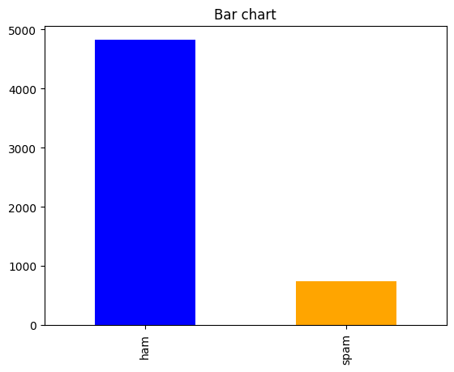

```python
# laod tha data
data = pd.read_csv('Data/sms_spam.csv', encoding='latin-1')
data = data.to_numpy()
X = data[:,1]
y = data[:,0]

#Show some data statistics
print("Data Stats:")
print("--------------------")
print("Class names: %s, %s" % (np.unique(y)[0], np.unique(y)[1]))
print("# Spam: %s" % np.sum(y=="spam"))
print("# Ham / Non-spam: %s" % np.sum(y=="ham"))
print("--------------------")

count_Class=pd.value_counts(y , sort= True)
count_Class.plot(kind= 'bar', color= ["blue", "orange"])
pyplot.title('Bar chart')
pyplot.show()
```

As you can see there is a significant imbalance between ham and spam samples. This is an issue for classification. We will discuss this later again.

Pre-process the data and create the train/validation split. The splits are then used in teh remaining sections. You should check the percentage of each datasplit if it makes sense for you. Make sure you have used a random state of 42.

```python
# Apply preprocessing function to all data samples in X
print("Preprocess data ... this may take 1-2 minutes ... ")
X_preprocessed = [processSMS(x) for x in X]

# train / validation split
print("Generating data splits ... ")
X_train, X_valid, y_train, y_valid = datasetSplits(X_preprocessed, y, verbose=1)
print(f'{X_train[0]=}')
```

[output not shown]

[output cut: 5556 more lines]

*You should now submit your solutions by executing the following cell.*

```python
# appends the implemented function to the grader object
grader.setFunc("datasetSplits", datasetSplits)
newfunc = grader.grade()
```

```
                          SMS Preprocessing |  15 /  15 | Nice work!
                             Dataset splits |  10 /  10 | Nice work!
                          Create Vocabulary |   0 /  20 | wrong
                               Word mapping |   0 /  15 | wrong
                         Feature Extraction |   0 /  10 | wrong
                               SVM Training |   0 /  10 | wrong
                      Hyperparameter Tuning |   0 /  20 | wrong
                                  --------------------------------
                                            |  25 / 100 |
```

## 3 Create Vocabulary

```python
def createVocabulary(trainingData, verbose=False):
    """
    Create the vocabulary based in a given (preprocessed) training data corpus.

    Parameters
    ----------

    trainingData : list
        List of pre-processed SMS strings where m is number of samples

    verbos: bool
        verbose flag to show the voablist

    Returns
    -------
    vocabList : list
        List of the 1000 most frequent words

    Instructions
    ------------
    Create a list of the 1000 most frequent words in training_data.
    Make sure trainig_data is already "normalized" (i.e. by executing the processSMS function before)


    """
    # The list of the final most frequent words
    vocabList = []

    # Look up the word in the dictionary and add to word_indices if found
    # ====================== YOUR CODE HERE ======================
    # create a list of all words in the training data
    all_words = [word for sms in trainingData for word in sms.split()] #unpack all worlds via split and list comprehension
    # count the occurences of each word
    word_counter = Counter(all_words)

    # sort the words by their occurences
    counter_tuple = word_counter.items() #returns a list of tuples with the word and the count
    sorted_words = sorted(counter_tuple,key=lambda x: x[1] ,reverse=True)
    #              sort    via tuple  ,by 2nd tuple elem, reverse order
    # take the 1000 most frequent words
    vocabList = [word for word, count in sorted_words[:1000]]


    # =============================================================


    if verbose:
        print('----------------')
        print('Vocabulary with size %d:' % len(vocabList))
        print('----------------')
        print(' '.join(vocabList))

    return vocabList
```

```python
# compute vocabulary only on training set.
# We don't wanna touch the validation set for this, since this would bias an objective evaluation.
print("Generating Vocabulary ... ")
vocabList = createVocabulary(X_train, verbose=1)
```

```
Generating Vocabulary ...
----------------
Vocabulary with size 1000:
----------------
number i to you a the u and in is me my for your it of call have on now that im are so not but or at do ur get can if will just be with no we lt gt this its up go ok when dont from free what how all know out got am good come then like was time only day love ill send there p want text txt going he on…
```

*You should now submit your solutions by executing the following cell.*

```python
# appends the implemented function to the grader object
grader.setValue("createVocabulary", vocabList)
newfunc = grader.grade()
```

```
                          SMS Preprocessing |  15 /  15 | Nice work!
                             Dataset splits |  10 /  10 | Nice work!
                          Create Vocabulary |  20 /  20 | Nice work!
                               Word mapping |   0 /  15 | wrong
                         Feature Extraction |   0 /  10 | wrong
                               SVM Training |   0 /  10 | wrong
                      Hyperparameter Tuning |   0 /  20 | wrong
                                  --------------------------------
                                            |  45 / 100 |
```

## 4 Word mapping

Your task now is to complete the code in the function `wordMapping` to perform this mapping. For each word in the (pre-processed) sms_content you should look up the word in the vocabulary list `vocabList`. If the word exists in the list, you should add the index of the word into the `word_indices` variable. If the word does not exist, and is therefore not in the vocabulary, you can skip the word.

**python tip**: In python, you can find the index of the first occurence of an item in `list` using the `index` attribute. In the provided code for `processSMS`, `vocabList` is a python list containing the words in the vocabulary. To find the index of a word, we can use `vocabList.index(word)` which would return a number indicating the index of the word within the list. If the word does not exist in the list, a `ValueError` exception is raised. In python, we can use the `try/except` statement to catch exceptions which we do not want to stop the program from running. You can think of the `try/except` statement to be the same as an `if/else` statement, but it asks for forgiveness rather than permission. An example would be:

```
try:
    do stuff here
except ValueError:
    pass
    # does nothing if a ValueError exception occured within the try statement
```

```python
def wordMapping(sms_content, vocabList, verbose=False):
    """
    Map words of the sms_content to indices in vocabList.

    Parameters
    ----------
    sms_content : str
        A string containing the original SMS string.

    vocabList : list
        List of the 1000 most frequent words

    verbose : bool
        If True, print the resulting indices.

    Returns
    -------
    word_indices : list
         List of word indices of each word in  sms_content (mapped to the index in vocabList)

    Instructions
    ------------
    Map words of the sms_content to indices in vocabList.
    Ignore all words not in vocabList.

    Concretely, if a SMS has the text:

        The quick brown fox jumped over the lazy dog.

    Then, the word_indices vector for this text might look  like:

        60  100  33  44  10  53  60  58  5

    where, we have mapped each word onto a an index in vocabList, for example:

        the   -- 60
        quick -- 100
        ...

    """

    # Init return value
    word_indices = []

    for word in sms_content.strip().split(" "):

        # Look up the word in the dictionary and add to word_indices if found
        # ====================== YOUR CODE HERE ======================
        if word in vocabList:
            word_indices.append(vocabList.index(word))

        # =============================================================

    if verbose:
        print('----------------')
        print('Word indices:')
        print('----------------')
        print(' '.join(word_indices))

    return word_indices
```

You can test the code with the SMS example again. This should give you:

```python
# Load data
with open(os.path.join('Data', 'smsSample1.txt')) as fid:
    file_contents = fid.read()

# normalize
processed_sms  = processSMS(file_contents)

# generate word mapping on created vocablist
word_indices  = wordMapping(processed_sms, vocabList)

#Print Stats
print('-------------')
print('Word Indices:')
print('-------------')
print(word_indices)
```

```
['here', 'is', 'your', 'discount³', 'code', 'rp', 'number', 'to', 'stop', 'further', 'messages˘', 'reply', 'stop', 'httpaddr', 'customer', 'services', 'number']
-------------
Word Indices:
-------------
[115, 9, 13, 435, 0, 2, 81, 565, 91, 81, 124, 244, 626, 0]
```

After you validated the results execute the function now on the training and validation sets.

```python
X_train_indices = [wordMapping(x, vocabList) for x in X_train]
X_valid_indices = [wordMapping(x, vocabList) for x in X_valid]
```

*You should now submit your solutions by executing the following cell.*

```python
# appends the implemented function to the grader object
grader.setFunc("wordMapping", wordMapping)
newfunc = grader.grade()
```

```
                          SMS Preprocessing |  15 /  15 | Nice work!
                             Dataset splits |  10 /  10 | Nice work!
                          Create Vocabulary |  20 /  20 | Nice work!
                               Word mapping |  15 /  15 | Nice work!
                         Feature Extraction |   0 /  10 | wrong
                               SVM Training |   0 /  10 | wrong
                      Hyperparameter Tuning |   0 /  20 | wrong
                                  --------------------------------
                                            |  60 / 100 |
```

## 5 Feature Extraction

After you have identified the index of each word in the vocabulary you can apply the method `featureExtraction` to extract the final feature vector for each SMS. The resulting feature vector is $\mathbb{R}^n$, with n = # words in vocabulary list. Specifically, the feature $x_i \in \{0, 1\}$ for an SMS corresponds to whether the $i^{th}$ word in the dictionary occurs in the SMS. That is, $x_i = 1$ if the $i^{th}$ word is in the SMS and $x_i = 0$ if the $i^{th}$ word is not present in the SMS.

Thus, for one SMS, this feature would look like:

$$ x = \begin{bmatrix} 0 & \dots & 1 & 0 & \dots & 1 & 0 & \dots & 0 \end{bmatrix}^T \in \mathbb{R}^n $$

You should now complete the code in the function `featureExtraction` to generate a feature vector for a SMS, given the `word_indices`.

```python
def featureExtraction(word_indices, vocabList):
    """
    Takes in a word_indices vector and produces a feature vector from the word indices.

    Parameters
    ----------
    word_indices : list
        A list of word indices from the vocabulary list.
    vocabList : list
        A list of the most frequent words used, i.e. the vocabulary.
        Here just for the sake to get the correct dimension of the feature vector (in case you would like to test other feature vector sizes)

    Returns
    -------
    x : list
        The computed feature vector.

    Instructions
    ------------
    Fill in this function to return a feature vector for the
    given SMS (i.e. word_indices).
    The variable `word_indices` contains the list of indices of the words
    which occur in one SMS and are mapped from the vocabulary.

    Note
    ----
    Your task is take one such `word_indices` vector and construct
    a binary feature vector that indicates whether a particular
    word occurs in the SNS. That is, x[i] = 1 when word i
    is present in the SMS. Concretely, if the word 'the' (say,
    index 60) appears in the SMS, then x[60] = 1. The feature
    vector should look like:
        x = [ 0 0 0 0 1 0 0 0 ... 0 0 0 0 1 ... 0 0 0 1 0 ..]
    """
    # Total number of words in the vocabulary
    n = len(vocabList)

    # You need to return the following variables correctly.
    x = np.zeros(n)

    # ===================== YOUR CODE HERE ======================
    for index in word_indices:
        x[index] = 1

    # ===========================================================

    return x
```

```python
# Extract Features
with open(os.path.join('Data', 'smsSample1.txt')) as fid:
    file_contents = fid.read()

processed_sms  = processSMS(file_contents)
word_indices  = wordMapping(processed_sms, vocabList)
feature  = featureExtraction(word_indices, vocabList)

#Print Stats
print('-------------')
print('Word Indices:')
print('-------------')
print('Length of vector: %d' % len(feature))
print('Non-zero entries in vector: %d' % np.sum(feature))
```

```
['here', 'is', 'your', 'discount³', 'code', 'rp', 'number', 'to', 'stop', 'further', 'messages˘', 'reply', 'stop', 'httpaddr', 'customer', 'services', 'number']
-------------
Word Indices:
-------------
Length of vector: 1000
Non-zero entries in vector: 12
```

After you validated the results of the function above let's apply it on the training and validation sets to extract our final training and validation features.

```python
X_train_features = [featureExtraction(x, vocabList) for x in X_train_indices]
X_valid_features = [featureExtraction(x, vocabList) for x in X_valid_indices]
```

*You should now submit your solutions.*

```python
# appends the implemented function to the grader object
grader.setFunc("featureExtraction", featureExtraction)
newfunc = grader.grade()
```

```
                          SMS Preprocessing |  15 /  15 | Nice work!
                             Dataset splits |  10 /  10 | Nice work!
                          Create Vocabulary |  20 /  20 | Nice work!
                               Word mapping |  15 /  15 | Nice work!
                         Feature Extraction |  10 /  10 | Nice work!
                               SVM Training |   0 /  10 | wrong
                      Hyperparameter Tuning |   0 /  20 | wrong
                                  --------------------------------
                                            |  70 / 100 |
```

## 6 SVM Training

In the following section we will train a SVM classifier using our extracted features from above. For training you use the trainig data split, for testing you use the validation data split.

For the SVM classifier you should use the `sklearn.svm.SVC` library. Please browse the documentation on https://scikit-learn.org/stable/modules/generated/sklearn.svm.SVC.html how to use this library. Use an initial regularization parameter of `C=1.0`. Per default the sklearn.svm.SVC is using Radial Basis Functions with an adapted sigma/gamma based on the feature variance and the number of samples. See documentation. Keep this default setting for now. After submitting you are free to try other kernel functions here.

IMPORTANT NOTE: If you look on the dataset more cloesely you will see that the amount of samples for each class (spam or ham) is quite unbalanced. This can be a problem for discriminative classifiers like SVM since classes with higher amount of samples have a larger influence in the optimization. To tackle this you have multiple options: it either makes sense to collect more data to make the amount of samples balanced or to give the samples of the class with a lower amount of samples more weight. With the parameter `class_weight='balanced'` you can weight the samples of the underrepresented class equal to the other class. Make sure you use this in all your SVM classifiers in this exercise.

Please fill in the code to train an SVM below.

```python
def svmTraining(X_train_features, y_train, C=1):
    """
    SVM trainig using extracted festures

    Parameters
    ----------
    X_train : array_like
        (o, ) matrix of training samples where o is number of training examples; here: variable length strings.
    X_valid : array_like
        (p, ) matrix of training samples where p is number of validation examples; here: variable length strings.
    C : float
        Regularization parameter of the SVM; Default: 1.0
    Return
    ----------
    svclassifier: object
        Classifier object (sklearn.svm.SVC)

    Instructions
    ------------
    Fill in this function to return a feature vector for the
    given SMS (i.e. word_indices).
    The variable `word_indices` contains the list of indices of the words
    which occur in one SMS and are mapped from the vocabulary.

    """

    svclassifier = None

    print('Training Linear SVM (for SMS Spam/Ham classification)')
    print('This may take 1 to 2 minutes ...\n')

    # Fill in the code for createing a classifier object and training it
    # ===================== YOUR CODE HERE ======================
    svclassifier = svm.SVC(kernel='linear', C=C)
    svclassifier.fit(X_train_features, y_train)

    # ===========================================================

    return svclassifier
```

Now execute the training function and return the classifier object.

```python
# executes the SVM training with a
svclassifier = svmTraining(X_train_features, y_train, C=1)
```

```
Training Linear SVM (for SMS Spam/Ham classification)
This may take 1 to 2 minutes ...
```

```python
# Compute the training accuracy
p_train = svclassifier.predict(X_train_features)
print('Training Accuracy: %.2f' % (np.mean(p_train == y_train) * 100))

p_valid = svclassifier.predict(X_valid_features)
print('Validation Accuracy: %.2f' % (np.mean(p_valid == y_valid) * 100))
np.set_printoptions(threshold=np.Inf)
```

```
Training Accuracy: 99.93
Validation Accuracy: 98.12
```

On the server I will use your parameters to evaluate against the held-out, unseen test set. This is the way how several big ML competitions make sure to have an objective evaluation of models.

```python
# appends the implemented function to the grader object
grader.setValue("svmTraining", list(p_valid))
newfunc = grader.grade()
```

```
                          SMS Preprocessing |  15 /  15 | Nice work!
                             Dataset splits |  10 /  10 | Nice work!
                          Create Vocabulary |  20 /  20 | Nice work!
                               Word mapping |  15 /  15 | Nice work!
                         Feature Extraction |  10 /  10 | Nice work!
                               SVM Training |  10 /  10 | Nice work!
                      Hyperparameter Tuning |   0 /  20 | wrong
                                  --------------------------------
                                            |  80 / 100 |
```

#### Prediction

Now you use your trained model to do a prediction on one test sample. Don't forget to pre-process the sample and extract the feature vector before feeding it into the predict method of your SVM model.

```python
def predict(svclassifier, sms_content):
    """
    Map words of the sms_content to indices in vocabList.

    Parameters
    ----------
    svcclassifier : object
        Your trained sklearn SVM classifier object

    sms_content : str
        A string containing the original SMS string.

    Results
    ----------
    prediction : int
        Binary class prediction in [0,1]: here [ham, spam]
    """
    pred_y = "Not predicted"

    # predict based on trained classiier model
    # ===================== YOUR CODE HERE ======================
    sms_content = processSMS(sms_content)
    indices = wordMapping(sms_content, vocabList)
    feature = featureExtraction(indices, vocabList)
    pred_y = svclassifier.predict([feature])[0] # Warum [0]? Weil predict eine Liste zurückgibt, die nur ein Element enthält

    # ===========================================================

    print('Test sample is: %s' % pred_y)
```

Predict based on loaded data sample and your trained classifier.

```python
# Extract Features
with open(os.path.join('Data', 'smsSample2.txt')) as fid:
    file_contents = fid.read()
print(file_contents)
predict(svclassifier, file_contents)
```

```
Its not the same here. Still looking for a job. How much do Ta's earn there.
['its', 'not', 'the', 'same', 'here', 'still', 'looking', 'for', 'a', 'job', 'how', 'much', 'do', "ta's", 'earn', 'there']
Test sample is: ham
```

## 7 Hyperparameter tuning

Your task is to use the validation set `X_valid`, `y_valid` to determine the best regularization parameter $C$ to use for trainnig the SVM. You should write any additional code necessary to help you search over the parameters $C$. We suggest trying values in multiplicative steps (e.g., 0.01, 0.1, 1, 10, 100, 1000, 10000).

**Implementation Tip:** When implementing cross validation to select the best $C$ parameter to use, you need to evaluate the error on the validation set. Recall that for classification, the error is defined as the fraction of the validation examples that were classified incorrectly. In `numpy`, you can compute this error using `np.mean(predictions != y_valid)`, where `predictions` is a vector containing all the predictions from the SVM, and `y_valid` are the true labels from the validation set. You can use the `svclassifier.predict` function to generate the predictions for the cross validation set. See also above.

```python
def hyperparameterTuning(X_train_features, y_train, X_valid_features, y_valid, C_array):
    """
    Hyperparamter tuning - regularization parameter C

    Parameters
    ----------
    X_train_features : array_like
        (m x n) matrix of training data where m is number of training examples, and
        n is the number of features.

    y_train : array_like
        (m, ) vector of labels for ther training data.

    X_valid_features : array_like
        (mv x n) matrix of validation data where mv is the number of validation examples
        and n is the number of features

    y_valid : array_like
        (mv, ) vector of labels for the validation data.

    C_array : list
        List of C values used in the parameter search.

    Returns
    -------
    err_array : list
        List of error values corresponding to the used parameters provided in C_array

    Instructions
    ------------
    Fill in this function to return the error for all parameters in C_array.
    You can use `svmPredict` to predict the labels on the
    validation set. For example,

        predictions = svclassifier.predict(X_valid_features)

    will return the predictions on the validation set.

    Note
    ----
    You can compute the prediction error using
        np.mean(predictions != y_valid)
    """
    err_array = []

    # Hyperparameter search on parameter C. Save the error values.
    # ====================== YOUR CODE HERE ======================
    for C in C_array: # iterate over all C values
        # svclassifier = svm.SVC(kernel='linear', C=C, class_weight='balanced')  # create a new classifier for each C value
        svclassifier = svm.SVC(C=C, class_weight='balanced')  # create a new classifier for each C value
        svclassifier.fit(X_train_features, y_train) # train the classifier
        predictions = svclassifier.predict(X_valid_features) # predict the validation set, validation set means that the model has not seen this data before
        err = np.mean(predictions != y_valid)   # calculate the error
        err_array.append(err) # append the error to the error array

    # ============================================================

    assert(len(err_array)==len(C_array))
    return err_array
```

Now let's use your `hyperparameterTuning` to compute the errors for a few C values to be able to select the best C value based on the error. Using the best C value we retrain our classifier which is then used for the remaining sections in this exercise.

```python
# Try different SVM Parameters here
C_array = np.array([0.01, 0.1, 1, 10, 100, 1000, 10000])
err_array = hyperparameterTuning(X_train_features, y_train, X_valid_features, y_valid, C_array)

# get the best C based on the computed error
err = np.array(err_array)
ind = np.unravel_index(np.argmin(err, axis = None), err.shape)
C = C_array[ind]

# Train SVM using the bes parameters
svclassifier = svm.SVC(C=C, class_weight="balanced")
svclassifier.fit(X_train_features, y_train)

# Compute the training accuracy
p_train = svclassifier.predict(X_train_features)
print('Training Accuracy: %.2f' % (np.mean(p_train == y_train) * 100))

p_valid = svclassifier.predict(X_valid_features)
print('Validation Accuracy: %.2f' % (np.mean(p_valid == y_valid) * 100))
np.set_printoptions(threshold=np.Inf)

# Test SVM trained with the best parameters on one sample
with open(os.path.join('Data', 'smsSample1.txt')) as fid:
    file_contents = fid.read()

predict(svclassifier, file_contents)
```

```
Training Accuracy: 99.93
Validation Accuracy: 98.48
['here', 'is', 'your', 'discount³', 'code', 'rp', 'number', 'to', 'stop', 'further', 'messages˘', 'reply', 'stop', 'httpaddr', 'customer', 'services', 'number']
Test sample is: spam
```

*You should now submit your solutions.*

```python
# appends the implemented function to the grader object
grader.setValue("hyperparameterTuning", err_array)
newfunc = grader.grade()
```

```
                          SMS Preprocessing |  15 /  15 | Nice work!
                             Dataset splits |  10 /  10 | Nice work!
                          Create Vocabulary |  20 /  20 | Nice work!
                               Word mapping |  15 /  15 | Nice work!
                         Feature Extraction |  10 /  10 | Nice work!
                               SVM Training |  10 /  10 | Nice work!
                      Hyperparameter Tuning |  20 /  20 | Nice work!
                                  --------------------------------
                                            | 100 / 100 |
```

## 8 ROC curve

In this last section your task is to visualize the error of your best classifier (found in last section). We use ROC cuves for that. In particular you should use the `sklearn.metrics.RocCurveDisplay` for this. For this function you need to use probabilty values. To receive a probability of your classifer and not only a binary answer (spam or ham) you can use the function `decision_function` on your classifier object to get the unnormalized decision score.

Note: Although we don't need probabilities to compute the ROC cource, note that we can also get real probabilities using those distance values by tuning a sigmoid function to these distance values. The parameters of the sigmoid function are learned using cross-validation and optimizing on the cross-entropy loss. See also [Platt Scaling](https://home.cs.colorado.edu/~mozer/Teaching/syllabi/6622/papers/Platt1999.pdf).

Your task: Please plot the ROC for the training and the validation samples. Your ROC curve should look similar to this one.

[figure not shown]

```python
# Your code for plotting the ROC curve on the training and validation dataset goes here. (Not graded in online submission)
# ====================== YOUR CODE HERE ======================
# Compute ROC curve and ROC area for each class
decision_score = svclassifier.decision_function(X_train_features)
fpr, tpr, thr = metrics.roc_curve(y_train, decision_score)
roc_auc = metrics.auc(fpr, tpr)

# ============================================================
```

[output not shown]

[output cut: 63 more lines]

You don't need to submit sth here.

## A.1 Optional (ungraded) exercise: Try your own SMS sample

You have a SMS which you don't know if it SPAM or HAM. Just try your created spam classifier on this SMS sample. Just save it as txt file and access and use it in the same way as you have used `smsSample1.txt` before.

*You do not need to submit any solutions for this optional (ungraded) exercise.*

## A.2 Optional (ungraded) exercise: Improve the vocabulary

One way to improve the vocabulary is to filter out common `stop words` in the pre-processing step. Stop words are the words in a stop list (or stoplist or negative dictionary) which are filtered out (i.e. stopped) before processing of natural language data (text) because they are insignificant. Try this and see how your classifier is improving. I copied a list of english stop words into the data folder. Find a [Lists of stop words in various languages here](https://www.ranks.nl/stopwords).

*You do not need to submit any solutions for this optional (ungraded) exercise.*

## A.3 One additional note on class balancing

In general when your goal is to have a high accuracy for ALL of your classes, class balancing makes sense.

In our SMS spam classification we rather go for false negatives (classified the a spam SMS as ham SMS) than for the false positive case (classified a ham SMS as spam SMS). The latter would mean that you will miss this SMS.

Having more samples on the HAM class will favor exactly this and one would rather avoid automatic balancing here.

Additionally, using the values in the ROC curves you are able to set the right level for your classifier (i.e. a low FP with a decent TPR) using the right threshold on the prediction results (i.e. the probabilities or the unnormalized distances).

## Uploading your PDF

Well done. You are now ready with this assignment. Please make sure that ALL code cells are executed and create a PDF from the notebook: Use the File-->Print... function in Juypter Lab (not via the Browser, and not export as PDF in Jupyter Lab). Upload this PDF to Moodle in the assignment section and in the correct assignment number.

## References

SMS Dataset: Almeida, Tiago A., José María G. Hidalgo, and Akebo Yamakami. "Contributions to the study of SMS spam filtering: new collection and results." Proceedings of the 11th ACM symposium on Document engineering. 2011.  
Notebook has been partly inspired from Andrew Ng, Machine Learning Coursera